# BELLABEAT CASE STUDY July 2022

Elena Olivo

July 23, 2022

#### Recent trends in smart device usage suggest health data collection by

#### users is an important feature with high engagement.

#### Bellabeat would like to engage their app users in new ways, by looking at

#### data from these smart devices to create new opportunities within the app.

#### The aim here is data exploration to discover insights that can benefit

#### Bellabeat, and find new ways to engage their app users.

#### Load packages:

#### * Tidyverse

#### * ggplot

#### * dplyr

#### * skimr, janitor, here

#### * reshape

# Examine health dataset to begin analysis

```r
head(health_data)
```

| Id | Date | WeightKg | WeightPounds | Fat | BMI | IsManualReport | LogId |
| --- | --- | --- | --- | --- | --- | --- | --- |
| 1503960366 | 5/2/16 23:59 | 52.6 | 115.9631 | 22 | 22.65 | TRUE | 1.46223e+12 |
| 1503960366 | 5/3/16 23:59 | 52.6 | 115.9631 | NA | 22.65 | TRUE | 1.46232e+12 |
| 1927972279 | 4/13/16 1:08 | 133.5 | 294.3171 | NA | 47.54 | FALSE | 1.46051e+12 |
| 2873212765 | 4/21/16 23:59 | 56.7 | 125.0021 | NA | 21.45 | TRUE | 1.46128e+12 |
| 2873212765 | 5/12/16 23:59 | 57.3 | 126.3249 | NA | 21.69 | TRUE | 1.46310e+12 |
| 4319703577 | 4/17/16 23:59 | 72.4 | 159.6147 | 25 | 27.45 | TRUE | 1.46094e+12 |

#### Cleaning data

```r
clean_names(health_data)
```

| id | date | weight_kg | weight_pounds | fat | bmi | is_manual_report | log_id |
| --- | --- | --- | --- | --- | --- | --- | --- |
| 1503960366 | 5/2/16 23:59 | 52.6 | 115.9631 | 22 | 22.65 | TRUE | 1.46223e+12 |
| 1503960366 | 5/3/16 23:59 | 52.6 | 115.9631 | NA | 22.65 | TRUE | 1.46232e+12 |
| 1927972279 | 4/13/16 1:08 | 133.5 | 294.3171 | NA | 47.54 | FALSE | 1.46051e+12 |
| 2873212765 | 4/21/16 23:59 | 56.7 | 125.0021 | NA | 21.45 | TRUE | 1.46128e+12 |
| 2873212765 | 5/12/16 23:59 | 57.3 | 126.3249 | NA | 21.69 | TRUE | 1.46310e+12 |
| 4319703577 | 4/17/16 23:59 | 72.4 | 159.6147 | 25 | 27.45 | TRUE | 1.46094e+12 |
| 4319703577 | 5/4/16 23:59 | 72.3 | 159.3942 | NA | 27.38 | TRUE | 1.46241e+12 |
| 4558609924 | 4/18/16 23:59 | 69.7 | 153.6622 | NA | 27.25 | TRUE | 1.46102e+12 |
| 4558609924 | 4/25/16 23:59 | 70.3 | 154.9850 | NA | 27.46 | TRUE | 1.46163e+12 |
| 4558609924 | 5/1/16 23:59 | 69.9 | 154.1031 | NA | 27.32 | TRUE | 1.46215e+12 |

[output cut: 57 more lines]

#### Organize and examine data Body Mass Index (BMI)

https://www.niddk.nih.gov/health-information/health-statistics/overweight-obesity

```r
health_data %>% arrange(-BMI)
```

| Id | Date | WeightKg | WeightPounds | Fat | BMI | IsManualReport | LogId |
| --- | --- | --- | --- | --- | --- | --- | --- |
| 1927972279 | 4/13/16 1:08 | 133.5 | 294.3171 | NA | 47.54 | FALSE | 1.46051e+12 |
| 5577150313 | 4/17/16 9:17 | 90.7 | 199.9593 | NA | 28.00 | FALSE | 1.46088e+12 |
| 4558609924 | 4/25/16 23:59 | 70.3 | 154.9850 | NA | 27.46 | TRUE | 1.46163e+12 |
| 4319703577 | 4/17/16 23:59 | 72.4 | 159.6147 | 25 | 27.45 | TRUE | 1.46094e+12 |
| 4319703577 | 5/4/16 23:59 | 72.3 | 159.3942 | NA | 27.38 | TRUE | 1.46241e+12 |
| 4558609924 | 5/1/16 23:59 | 69.9 | 154.1031 | NA | 27.32 | TRUE | 1.46215e+12 |
| 4558609924 | 4/18/16 23:59 | 69.7 | 153.6622 | NA | 27.25 | TRUE | 1.46102e+12 |
| 4558609924 | 5/2/16 23:59 | 69.2 | 152.5599 | NA | 27.04 | TRUE | 1.46223e+12 |
| 4558609924 | 5/9/16 23:59 | 69.1 | 152.3394 | NA | 27.00 | TRUE | 1.46284e+12 |
| 8877689391 | 4/12/16 6:47 | 85.8 | 189.1566 | NA | 25.68 | FALSE | 1.46044e+12 |

[output cut: 57 more lines]

#### BMI by healthy ratio (under 24.9)

```r
filter(health_data, BMI <=24.9)
```

| Id | Date | WeightKg | WeightPounds | Fat | BMI | IsManualReport | LogId |
| --- | --- | --- | --- | --- | --- | --- | --- |
| 1503960366 | 5/2/16 23:59 | 52.6 | 115.9631 | 22 | 22.65 | TRUE | 1.46223e+12 |
| 1503960366 | 5/3/16 23:59 | 52.6 | 115.9631 | NA | 22.65 | TRUE | 1.46232e+12 |
| 2873212765 | 4/21/16 23:59 | 56.7 | 125.0021 | NA | 21.45 | TRUE | 1.46128e+12 |
| 2873212765 | 5/12/16 23:59 | 57.3 | 126.3249 | NA | 21.69 | TRUE | 1.46310e+12 |
| 6962181067 | 4/12/16 23:59 | 62.5 | 137.7889 | NA | 24.39 | TRUE | 1.46051e+12 |
| 6962181067 | 4/13/16 23:59 | 62.1 | 136.9071 | NA | 24.24 | TRUE | 1.46059e+12 |
| 6962181067 | 4/14/16 23:59 | 61.7 | 136.0252 | NA | 24.10 | TRUE | 1.46068e+12 |
| 6962181067 | 4/15/16 23:59 | 61.5 | 135.5843 | NA | 24.00 | TRUE | 1.46076e+12 |
| 6962181067 | 4/16/16 23:59 | 62.0 | 136.6866 | NA | 24.21 | TRUE | 1.46085e+12 |
| 6962181067 | 4/17/16 23:59 | 61.4 | 135.3638 | NA | 23.96 | TRUE | 1.46094e+12 |

[output cut: 24 more lines]

#### BMI Analysis unhealthy level (over 25.0)

```r
filter(health_data, BMI > 25.0)
```

| Id | Date | WeightKg | WeightPounds | Fat | BMI | IsManualReport | LogId |
| --- | --- | --- | --- | --- | --- | --- | --- |
| 1927972279 | 4/13/16 1:08 | 133.5 | 294.3171 | NA | 47.54 | FALSE | 1.46051e+12 |
| 4319703577 | 4/17/16 23:59 | 72.4 | 159.6147 | 25 | 27.45 | TRUE | 1.46094e+12 |
| 4319703577 | 5/4/16 23:59 | 72.3 | 159.3942 | NA | 27.38 | TRUE | 1.46241e+12 |
| 4558609924 | 4/18/16 23:59 | 69.7 | 153.6622 | NA | 27.25 | TRUE | 1.46102e+12 |
| 4558609924 | 4/25/16 23:59 | 70.3 | 154.9850 | NA | 27.46 | TRUE | 1.46163e+12 |
| 4558609924 | 5/1/16 23:59 | 69.9 | 154.1031 | NA | 27.32 | TRUE | 1.46215e+12 |
| 4558609924 | 5/2/16 23:59 | 69.2 | 152.5599 | NA | 27.04 | TRUE | 1.46223e+12 |
| 4558609924 | 5/9/16 23:59 | 69.1 | 152.3394 | NA | 27.00 | TRUE | 1.46284e+12 |
| 5577150313 | 4/17/16 9:17 | 90.7 | 199.9593 | NA | 28.00 | FALSE | 1.46088e+12 |
| 8877689391 | 4/12/16 6:47 | 85.8 | 189.1566 | NA | 25.68 | FALSE | 1.46044e+12 |

[output cut: 23 more lines]

#### Examine and observations

```r
health_data %>% summarize(mean_BMI = mean(BMI))
```

| mean_BMI |
| --- |
| 25.18522 |

#### Data examination

```r
health_data %>% summarize(max_BMI = max(BMI))
```

[output not shown]

#### Analysis: Mean BMI 25.1, and (one outlier of 47.54). Target users by BMI greater than 24.9 (unhealthy BMI)?

```r
health_data %>% arrange(-BMI)
```

| Id | Date | WeightKg | WeightPounds | Fat | BMI | IsManualReport | LogId |
| --- | --- | --- | --- | --- | --- | --- | --- |
| 1927972279 | 4/13/16 1:08 | 133.5 | 294.3171 | NA | 47.54 | FALSE | 1.46051e+12 |
| 5577150313 | 4/17/16 9:17 | 90.7 | 199.9593 | NA | 28.00 | FALSE | 1.46088e+12 |
| 4558609924 | 4/25/16 23:59 | 70.3 | 154.9850 | NA | 27.46 | TRUE | 1.46163e+12 |
| 4319703577 | 4/17/16 23:59 | 72.4 | 159.6147 | 25 | 27.45 | TRUE | 1.46094e+12 |
| 4319703577 | 5/4/16 23:59 | 72.3 | 159.3942 | NA | 27.38 | TRUE | 1.46241e+12 |
| 4558609924 | 5/1/16 23:59 | 69.9 | 154.1031 | NA | 27.32 | TRUE | 1.46215e+12 |
| 4558609924 | 4/18/16 23:59 | 69.7 | 153.6622 | NA | 27.25 | TRUE | 1.46102e+12 |
| 4558609924 | 5/2/16 23:59 | 69.2 | 152.5599 | NA | 27.04 | TRUE | 1.46223e+12 |
| 4558609924 | 5/9/16 23:59 | 69.1 | 152.3394 | NA | 27.00 | TRUE | 1.46284e+12 |
| 8877689391 | 4/12/16 6:47 | 85.8 | 189.1566 | NA | 25.68 | FALSE | 1.46044e+12 |

[output cut: 57 more lines]

## New dataset

```r
health_data2 <- health_data %>% arrange(-BMI)
```

#### Examine with a plot

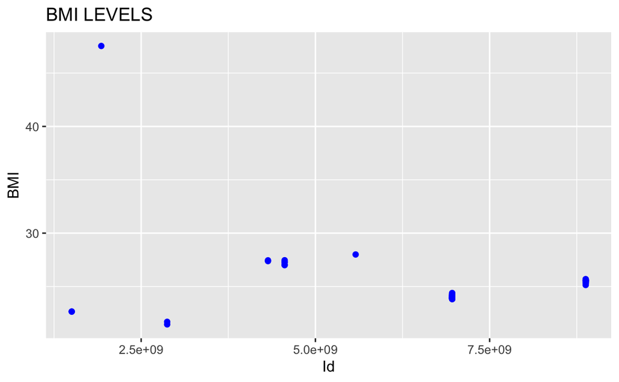

```r
ggplot(data= health_data2) +
  geom_point(mapping=aes(x=Id, y=BMI), color ="blue") +
  labs(title = "BMI LEVELS")
```

### One OUTLIER of BMI = 47.54

### Density plot for another look at data

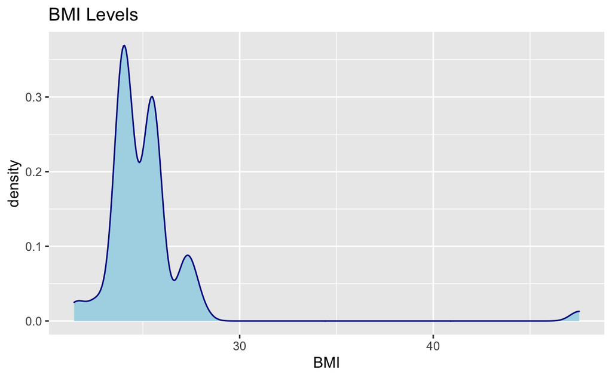

```r
ggplot(health_data2, aes(x=BMI)) +
  geom_density(color = "darkblue", fill = "lightblue") +
  labs(title = "BMI Levels")
```

#### Analysis: Mean BMI levels 25. Target this level and higher.

## Sleep pattern analysis

```r
head(sleep_data)
```

| Id | SleepDay | TotalSleepRecords | TotalMinutesAsleep | TotalTimeInBed |
| --- | --- | --- | --- | --- |
| 1503960366 | 4/12/16 0:00 | 1 | 327 | 346 |
| 1503960366 | 4/13/16 0:00 | 2 | 384 | 407 |
| 1503960366 | 4/15/16 0:00 | 1 | 412 | 442 |
| 1503960366 | 4/16/16 0:00 | 2 | 340 | 367 |
| 1503960366 | 4/17/16 0:00 | 1 | 700 | 712 |
| 1503960366 | 4/19/16 0:00 | 1 | 304 | 320 |

#### Look at Sleep data

```r
clean_names(sleep_data)
```

| id | sleep_day | total_sleep_records | total_minutes_asleep | total_time_in_bed |
| --- | --- | --- | --- | --- |
| 1503960366 | 4/12/16 0:00 | 1 | 327 | 346 |
| 1503960366 | 4/13/16 0:00 | 2 | 384 | 407 |
| 1503960366 | 4/15/16 0:00 | 1 | 412 | 442 |
| 1503960366 | 4/16/16 0:00 | 2 | 340 | 367 |
| 1503960366 | 4/17/16 0:00 | 1 | 700 | 712 |
| 1503960366 | 4/19/16 0:00 | 1 | 304 | 320 |
| 1503960366 | 4/20/16 0:00 | 1 | 360 | 377 |
| 1503960366 | 4/21/16 0:00 | 1 | 325 | 364 |
| 1503960366 | 4/23/16 0:00 | 1 | 361 | 384 |
| 1503960366 | 4/24/16 0:00 | 1 | 430 | 449 |

[output cut: 403 more lines]

#### Analyze by unique Id

```r
sleep_data %>% group_by(Id, SleepDay) %>% drop_na() %>% summarize(max_bed=max(TotalTimeInBed),
max_sleep=max(TotalMinutesAsleep))
```

[output not shown]

| Id | SleepDay | max_bed | max_sleep |
| --- | --- | --- | --- |
| 1503960366 | 4/12/16 0:00 | 346 | 327 |
| 1503960366 | 4/13/16 0:00 | 407 | 384 |
| 1503960366 | 4/15/16 0:00 | 442 | 412 |
| 1503960366 | 4/16/16 0:00 | 367 | 340 |
| 1503960366 | 4/17/16 0:00 | 712 | 700 |
| 1503960366 | 4/19/16 0:00 | 320 | 304 |
| 1503960366 | 4/20/16 0:00 | 377 | 360 |
| 1503960366 | 4/21/16 0:00 | 364 | 325 |
| 1503960366 | 4/23/16 0:00 | 384 | 361 |
| 1503960366 | 4/24/16 0:00 | 449 | 430 |

[output cut: 400 more lines]

#### Analyze data by ID

```r
user_0366 %>% filter(Id ==1503960366)
```

| Id | SleepDay | max_bed | max_sleep |
| --- | --- | --- | --- |
| 1503960366 | 4/12/16 0:00 | 346 | 327 |
| 1503960366 | 4/13/16 0:00 | 407 | 384 |
| 1503960366 | 4/15/16 0:00 | 442 | 412 |
| 1503960366 | 4/16/16 0:00 | 367 | 340 |
| 1503960366 | 4/17/16 0:00 | 712 | 700 |
| 1503960366 | 4/19/16 0:00 | 320 | 304 |
| 1503960366 | 4/20/16 0:00 | 377 | 360 |
| 1503960366 | 4/21/16 0:00 | 364 | 325 |
| 1503960366 | 4/23/16 0:00 | 384 | 361 |
| 1503960366 | 4/24/16 0:00 | 449 | 430 |

[output cut: 15 more lines]

#### Filter by Id

```r
head(user_1503)
```

| Id | SleepDay | max_bed | max_sleep |
| --- | --- | --- | --- |
| 1503960366 | 4/12/16 0:00 | 346 | 327 |
| 1503960366 | 4/13/16 0:00 | 407 | 384 |
| 1503960366 | 4/15/16 0:00 | 442 | 412 |
| 1503960366 | 4/16/16 0:00 | 367 | 340 |
| 1503960366 | 4/17/16 0:00 | 712 | 700 |
| 1503960366 | 4/19/16 0:00 | 320 | 304 |

#### Analysis: Make note that more time in bed than sleeping = Meditation exercise?

https://www.healthline.com/health/meditation-for-sleep

### Select unique ID (1503) for analysis with a scatterplot

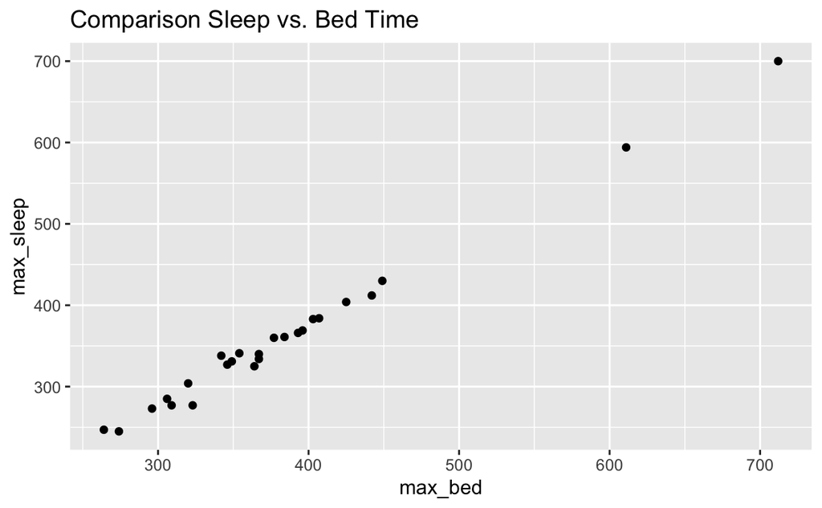

```r
ggplot(user_1503, mapping=aes(x=max_bed, y=max_sleep)) +
  geom_point() +
  labs(title = "Comparison Sleep vs. Bed Time")
```

#### Create new dataframes for better plot (specific observations from month)

```r
x <- c(346, 407, 442, 367, 712, 320, 377, 364, 384, 449, 323, 274, 393, 354)
y <- c(327, 384, 412, 340, 700, 304, 360, 325, 361, 430, 277, 245, 366, 341)
day <- c(12, 13, 15, 16, 17, 19, 20, 21, 23, 24, 25, 26, 28, 29)
```

#### Step 2 of creating new dataframes

```r
df1 <- data.frame(x, y, day)
df2 <- melt(df1, id.vars='day')
head(df2)
```

|  | day | variable | value |
| --- | --- | --- | --- |
| 1 | 12 | x | 346 |
| 2 | 13 | x | 407 |
| 3 | 15 | x | 442 |
| 4 | 16 | x | 367 |
| 5 | 17 | x | 712 |
| 6 | 19 | x | 320 |

### New plot style to better show comparison

#### (x = Max in-bed time, y = time asleep).

#### Small set of objects from dataset used for visualization.

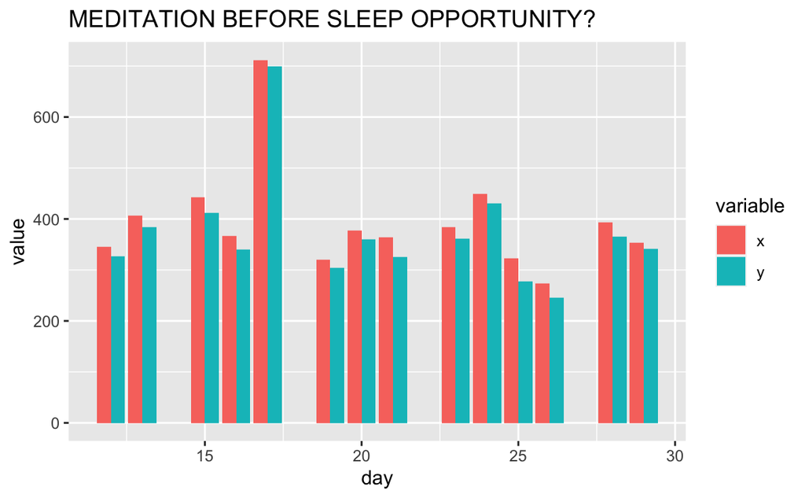

```r
ggplot(df2, aes(x=day, y=value, fill=variable)) +
    geom_bar(stat='identity', position='dodge') +
    labs(title = "MEDITATION BEFORE SLEEP OPPORTUNITY?")
```

#### Analysis: Suggest meditation exercise through app (*audible*?)

## Correlation between steps and calories by day?

```r
nrow(steps_by_day)
```

```
[1] 940
```

```r
nrow(calories_by_day)
```

```
[1] 940
```

#### Steps data (daily)

```r
steps_by_day %>%
  summary()
```

```
       Id            ActivityDay          StepTotal
 Min.   :1.504e+09   Length:940         Min.   :    0
 1st Qu.:2.320e+09   Class :character   1st Qu.: 3790
 Median :4.445e+09   Mode  :character   Median : 7406
 Mean   :4.855e+09                      Mean   : 7638
 3rd Qu.:6.962e+09                      3rd Qu.:10727
 Max.   :8.878e+09                      Max.   :36019
```

#### Calories data - daily

```r
calories_by_day %>%
  summary()
```

```
       Id            ActivityDay           Calories
 Min.   :1.504e+09   Length:940         Min.   :   0
 1st Qu.:2.320e+09   Class :character   1st Qu.:1828
 Median :4.445e+09   Mode  :character   Median :2134
 Mean   :4.855e+09                      Mean   :2304
 3rd Qu.:6.962e+09                      3rd Qu.:2793
 Max.   :8.878e+09                      Max.   :4900
```

#### Clean data

```r
clean_names(steps_by_day)
```

| id | activity_day | step_total |
| --- | --- | --- |
| 1503960366 | 4/12/16 | 13162 |
| 1503960366 | 4/13/16 | 10735 |
| 1503960366 | 4/14/16 | 10460 |
| 1503960366 | 4/15/16 | 9762 |
| 1503960366 | 4/16/16 | 12669 |
| 1503960366 | 4/17/16 | 9705 |
| 1503960366 | 4/18/16 | 13019 |
| 1503960366 | 4/19/16 | 15506 |
| 1503960366 | 4/20/16 | 10544 |
| 1503960366 | 4/21/16 | 9819 |

[output cut: 930 more lines]

#### Clean Data

```r
clean_names(calories_by_day)
```

| id | activity_day | calories |
| --- | --- | --- |
| 1503960366 | 4/12/16 | 1985 |
| 1503960366 | 4/13/16 | 1797 |
| 1503960366 | 4/14/16 | 1776 |
| 1503960366 | 4/15/16 | 1745 |
| 1503960366 | 4/16/16 | 1863 |
| 1503960366 | 4/17/16 | 1728 |
| 1503960366 | 4/18/16 | 1921 |
| 1503960366 | 4/19/16 | 2035 |
| 1503960366 | 4/20/16 | 1786 |
| 1503960366 | 4/21/16 | 1775 |

[output cut: 930 more lines]

#### Combine datasets

```r
stepscal_1 <-merge(steps_by_day, calories_by_day, by = c("Id", "ActivityDay"))
```

#### Look at combination dataset

```r
head(stepscal_1)
```

|  | Id | ActivityDay | StepTotal | Calories |
| --- | --- | --- | --- | --- |
| 1 | 1503960366 | 4/12/16 | 13162 | 1985 |
| 2 | 1503960366 | 4/13/16 | 10735 | 1797 |
| 3 | 1503960366 | 4/14/16 | 10460 | 1776 |
| 4 | 1503960366 | 4/15/16 | 9762 | 1745 |
| 5 | 1503960366 | 4/16/16 | 12669 | 1863 |
| 6 | 1503960366 | 4/17/16 | 9705 | 1728 |

#### Arrange dataset

```r
arrange(stepscal_1, desc(StepTotal))
```

| Id | ActivityDay | StepTotal | Calories |
| --- | --- | --- | --- |
| 1624580081 | 5/1/16 | 36019 | 2690 |
| 8877689391 | 4/16/16 | 29326 | 4547 |
| 8877689391 | 4/30/16 | 27745 | 4398 |
| 8877689391 | 4/27/16 | 23629 | 3808 |
| 8877689391 | 4/12/16 | 23186 | 3921 |
| 8053475328 | 4/24/16 | 22988 | 3577 |
| 4388161847 | 5/7/16 | 22770 | 4022 |
| 8053475328 | 4/23/16 | 22359 | 3554 |
| 2347167796 | 4/16/16 | 22244 | 2670 |
| 8053475328 | 5/8/16 | 22026 | 3589 |

[output cut: 930 more lines]

#### Any trends via plot?

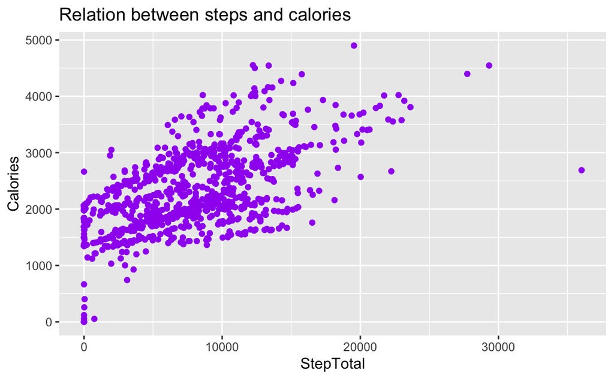

```r
ggplot(data=stepscal_1) +
   geom_point(mapping=aes(x=StepTotal, y=Calories), color="purple") +
   labs(title = "Relation between steps and calories")
```

#### Another plot with smooth feature

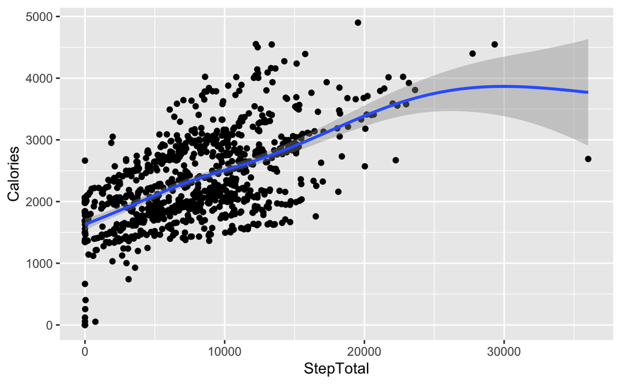

```r
ggplot(stepscal_1, aes(x= StepTotal, y= Calories)) +
  geom_point() +
  geom_smooth(method="gam",
formula = y ~s(x))
```

#### Analysis: More steps, more calories burned!

## New Steps/Calories analysis: Look at data, target by unique Id, patterns?

```r
glimpse(hourly_steps_v1)
```

```
Rows: 22,099
Columns: 3
$ Id           <dbl> 1503960366, 1503960366, 1503960366, 1503960366, 15039603…
$ ActivityHour <chr> "4/12/16 0:00", "4/12/16 1:00", "4/12/16 2:00", "4/12/16…
$ StepTotal    <dbl> 373, 160, 151, 0, 0, 0, 0, 0, 250, 1864, 676, 360, 253, …
```

#### Review data

```r
glimpse(hourly_calories_v1)
```

```
Rows: 22,099
Columns: 3
$ Id           <dbl> 1503960366, 1503960366, 1503960366, 1503960366, 15039603…
$ ActivityHour <chr> "4/12/16 0:00", "4/12/16 1:00", "4/12/16 2:00", "4/12/16…
$ Calories     <dbl> 81, 61, 59, 47, 48, 48, 48, 47, 68, 141, 99, 76, 73, 66,…
```

#### Merge datasets

```r
combined_dataV2 <-inner_join(hourly_calories_v1, hourly_steps_v1, by = c("Id", "ActivityHour"))
```

#### Filter by Id

```r
combined_dataV2 %>% filter(Id == "4702921684")
```

| Id | ActivityHour | Calories | StepTotal |
| --- | --- | --- | --- |
| 4702921684 | 4/12/16 0:00 | 84 | 0 |
| 4702921684 | 4/12/16 1:00 | 85 | 0 |
| 4702921684 | 4/12/16 2:00 | 85 | 0 |
| 4702921684 | 4/12/16 3:00 | 87 | 4 |
| 4702921684 | 4/12/16 4:00 | 84 | 0 |
| 4702921684 | 4/12/16 5:00 | 85 | 0 |
| 4702921684 | 4/12/16 6:00 | 149 | 558 |
| 4702921684 | 4/12/16 7:00 | 115 | 177 |
| 4702921684 | 4/12/16 8:00 | 157 | 446 |
| 4702921684 | 4/12/16 9:00 | 204 | 1264 |

[output cut: 721 more lines]

#### View data for creation of alert system of low activity points in day

```r
user_1684 %>%
  select(ActivityHour,
         Calories,
         StepTotal) %>%
  summary()
```

```
 ActivityHour          Calories       StepTotal
 Length:731         Min.   : 84.0   Min.   :   0.0
 Class :character   1st Qu.: 85.0   1st Qu.:   0.0
 Mode  :character   Median :108.0   Median : 149.0
                    Mean   :125.7   Mean   : 363.3
                    3rd Qu.:157.5   3rd Qu.: 556.0
                    Max.   :399.0   Max.   :3962.0
```

#### Subset of rows

```r
user_1684v2 <- user_1684[c(1:24), c(2,3:4)]
```

#### Arrange subset

```r
arrange(user_1684v2)
```

| ActivityHour | Calories | StepTotal |
| --- | --- | --- |
| 4/12/16 0:00 | 84 | 0 |
| 4/12/16 1:00 | 85 | 0 |
| 4/12/16 2:00 | 85 | 0 |
| 4/12/16 3:00 | 87 | 4 |
| 4/12/16 4:00 | 84 | 0 |
| 4/12/16 5:00 | 85 | 0 |
| 4/12/16 6:00 | 149 | 558 |
| 4/12/16 7:00 | 115 | 177 |
| 4/12/16 8:00 | 157 | 446 |
| 4/12/16 9:00 | 204 | 1264 |

[output cut: 14 more lines]

#### Plot

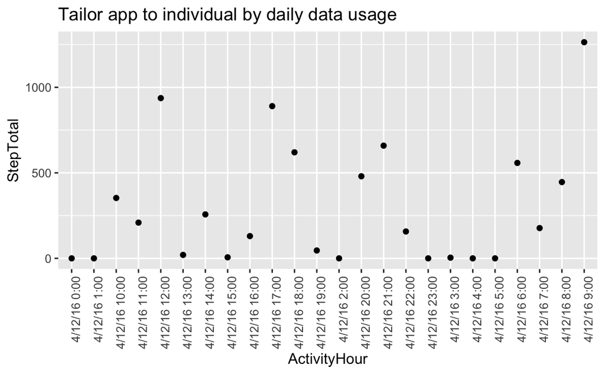

```r
ggplot(user_1684v2) +
  geom_point(mapping = aes(x=ActivityHour, y=StepTotal)) +
  theme(axis.text.x = element_text(angle = 90, hjust = 1)) +
  labs(title = "Tailor app to individual by daily data usage")
```

#### During lower points of activity during day, perhaps an opportunity

#### to engage user to be more active via alert?

## New dataset on steps

```r
head(hourly_intense_active2)
```

| Id | ActivityHour | TotalIntensity | AverageIntensity |
| --- | --- | --- | --- |
| 5577150313 | 4/16/16 14:00 | 180 | 3.000000 |
| 8877689391 | 4/15/16 18:00 | 180 | 3.000000 |
| 8877689391 | 4/30/16 14:00 | 180 | 3.000000 |
| 8877689391 | 5/7/16 13:00 | 180 | 3.000000 |
| 8053475328 | 4/16/16 19:00 | 179 | 2.983333 |
| 8583815059 | 4/27/16 15:00 | 178 | 2.966667 |

#### Summary of dataset

```r
colnames(hourly_intense_active2)
```

```
[1] "Id"               "ActivityHour"     "TotalIntensity"   "AverageIntensity"
```

```r
summary(hourly_intense_active2, 50)
```

```
       Id            ActivityHour       TotalIntensity   AverageIntensity
 Min.   :1.504e+09   Length:22099       Min.   :  0.00   Min.   :0.0000
 1st Qu.:2.320e+09   Class :character   1st Qu.:  0.00   1st Qu.:0.0000
 Median :4.445e+09   Mode  :character   Median :  3.00   Median :0.0500
 Mean   :4.848e+09                      Mean   : 12.04   Mean   :0.2006
 3rd Qu.:6.962e+09                      3rd Qu.: 16.00   3rd Qu.:0.2667
 Max.   :8.878e+09                      Max.   :180.00   Max.   :3.0000
```

#### Plot for analysis

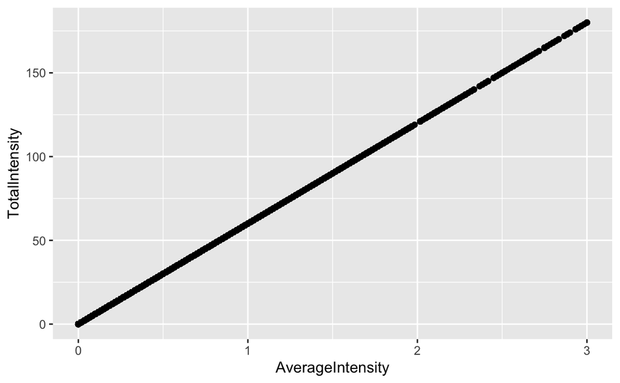

```r
ggplot(data=hourly_intense_active2) +
geom_point(mapping =aes (x=AverageIntensity, y=TotalIntensity))
```

```r
NA
```

#### Subset for patterns or trends by unique user Id

```r
user_9391 <-hourly_intense_active2 %>% filter(Id == "8877689391")
```

#### Get summary data

```r
min(user_9391$ActivityHour)
```

```
[1] "4/12/16 0:00"
```

#### Get additional summary data

```r
max(user_9391$ActivityHour)
```

```
[1] "5/9/16 9:00"
```

#### Can this data be used to explain higher activity on a particular day/hour?

#### Additional look at unique Id

```r
user_9391 %>% arrange(ActivityHour)
```

| Id | ActivityHour | TotalIntensity | AverageIntensity |
| --- | --- | --- | --- |
| 8877689391 | 4/12/16 0:00 | 0 | 0.000000 |
| 8877689391 | 4/12/16 1:00 | 0 | 0.000000 |
| 8877689391 | 4/12/16 10:00 | 12 | 0.200000 |
| 8877689391 | 4/12/16 11:00 | 52 | 0.866667 |
| 8877689391 | 4/12/16 12:00 | 158 | 2.633333 |
| 8877689391 | 4/12/16 13:00 | 9 | 0.150000 |
| 8877689391 | 4/12/16 14:00 | 1 | 0.016667 |
| 8877689391 | 4/12/16 15:00 | 32 | 0.533333 |
| 8877689391 | 4/12/16 16:00 | 21 | 0.350000 |
| 8877689391 | 4/12/16 17:00 | 51 | 0.850000 |

[output cut: 725 more lines]

#### Subset by Id and sample of data

```r
head(user_9391, 24) %>% arrange(ActivityHour)
```

| Id | ActivityHour | TotalIntensity | AverageIntensity |
| --- | --- | --- | --- |
| 8877689391 | 4/12/16 12:00 | 158 | 2.633333 |
| 8877689391 | 4/13/16 18:00 | 160 | 2.666667 |
| 8877689391 | 4/14/16 16:00 | 148 | 2.466667 |
| 8877689391 | 4/15/16 18:00 | 180 | 3.000000 |
| 8877689391 | 4/15/16 19:00 | 127 | 2.116667 |
| 8877689391 | 4/16/16 12:00 | 140 | 2.333333 |
| 8877689391 | 4/17/16 18:00 | 161 | 2.683333 |
| 8877689391 | 4/19/16 16:00 | 173 | 2.883333 |
| 8877689391 | 4/20/16 18:00 | 173 | 2.883333 |
| 8877689391 | 4/22/16 18:00 | 133 | 2.216667 |

[output cut: 14 more lines]

#### View new subset dataframe

```r
head(user_9391v2)
```

| Id | ActivityHour | TotalIntensity | AverageIntensity |
| --- | --- | --- | --- |
| 8877689391 | 4/12/16 12:00 | 158 | 2.633333 |
| 8877689391 | 4/13/16 18:00 | 160 | 2.666667 |
| 8877689391 | 4/14/16 16:00 | 148 | 2.466667 |
| 8877689391 | 4/15/16 18:00 | 180 | 3.000000 |
| 8877689391 | 4/15/16 19:00 | 127 | 2.116667 |
| 8877689391 | 4/16/16 12:00 | 140 | 2.333333 |

#### Plot this subset

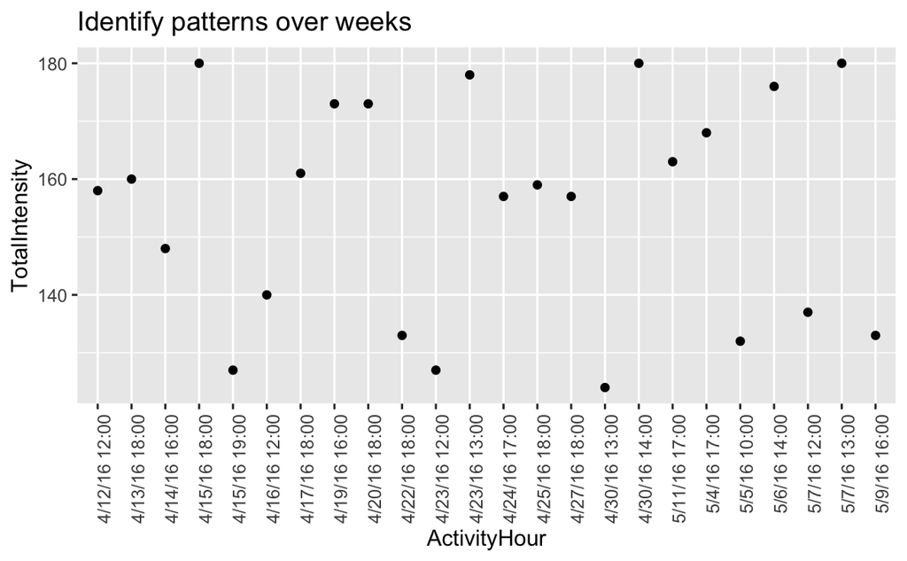

```r
ggplot(data = user_9391v2) +
  geom_point(mapping = aes(x=ActivityHour, y = TotalIntensity)) +
    theme(axis.text.x = element_text(angle = 90, hjust = 1)) +
    labs(title = "Identify patterns over weeks")
```

#### Another style of plot

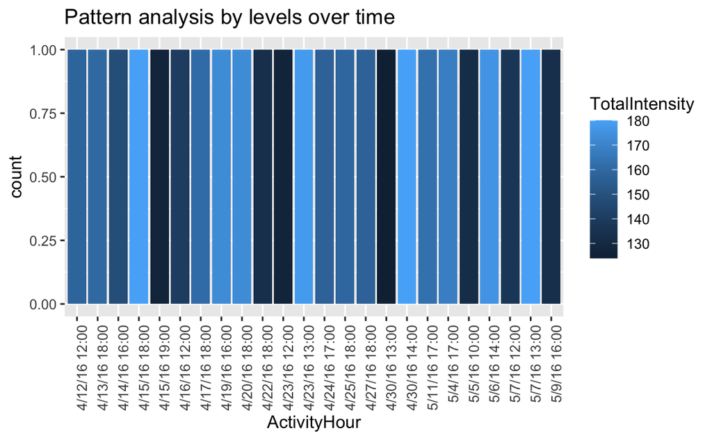

```r
ggplot(data = user_9391v2) +
  geom_bar(mapping = aes(x=ActivityHour, fill = TotalIntensity)) +
  theme(axis.text.x = element_text(angle = 90, hjust = 1)) +
  labs(title="Pattern analysis by levels over time")
```

#### Follow up survey to identify days/hours when activity is low vs. high and why?

# SUMMARY

#### * Target users via app by Body Mass Index (BMI): Diet and nutrition programs by BMI level?

#### * Alert users via app when BMI is approaching unhealthy level (*audible*)

#### * Create meditation exercise through app for bedtime (*before* / *after*)

#### * Target individuals via app to increase activity levels during low periods of activity (*day*/*week*)

#### * Use surveys via app to question users on periods of low activity vs. high activity?

## DATASET REFERENCE

https://www.kaggle.com/datasets/arashnic/fitbit

## SMART WATCH DATA RESEARCH/TRENDS

https://www.delveinsight.com/blog/wearable-technology-trends-2022

https://www.crn.com/slide-shows/internet-of-things/ces-2022-10-wearable-technologies-for-health-safety-fitness#.YpaevEdbhEE.link